# Project 2 by Isabel Coupland

## Introduction

##### Scientific question: What genetic changes in the auditory processing pathway of mammals allow for high-frequency hearing, leading to the convergent evolution of echolocation?

Echolocation is the location of objects using reflected sound. Three species of mammals that use echolocation are Eptesicus fuscus (Big brown bat), Hipposideros armiger (Great roundleaf bat), and Orcinus orca (Killer whale). Three mammals that cannot echolocate are Cynopterus sphinx (Greater short-nosed fruit bat), Pteropus vampyrus (Large flying fox), and Homo sapiens.

Some genes known to be involved with the auditory pathway and hearing loss include:

- Prestin (SLC26A5; involved in cochlear hair cell motility and ion exchange, critical for hearing sensitivity),
- GJB2 (associated with hearing loss in humans),
- CDH23 (responsible for stereocilia organization and hair bundle formation),
- PCDH15 (maintenance of normal retinal and cochlear function),
- OTOF (vesicle membrane fusion, associated with deafness in mice), and
- KCNQ4 (cochlear neuron excitability).

The data used in this project was sourced from NCBI Nucleotide and NCBI GEO:

- NCBI Nucleotide https://www.ncbi.nlm.nih.gov/nuccore As stated on this databases website, "The Nucleotide database is a collection of sequences from several sources, including GenBank, RefSeq, TPA and PDB. Genome, gene and transcript sequence data provide the foundation for biomedical research and discovery."
- NCBI GEO https://www.ncbi.nlm.nih.gov/geo/ As stated on this website, "GEO is a public functional genomics data repository supporting MIAME-compliant data submissions. Array- and sequence-based data are accepted. Tools are provided to help users query and download experiments and curated gene expression profiles."

##### Scientific hypothesis: If there are similar changes in the sequences and expression of hearing-related genes in the brain of mammals, then an auditory processing pathway will evolve, allowing for the use of echolocation.

The coding sequences of each gene for all 6 species listed above were downloaded as a FASTA file from NCBI nucleotide. The sequences for each species was then compiled into one file for each gene and Multiple sequence alignment was performed using Clustalw2. A phylogenetic tree was created for the alignment of each gene.

- Multiple sequence alignment allows me to compare the sequences of a gene for each species, then plot it using a phylogenetic tree to determine which gene(s) are most similar among echolocating species.

RNA-Seq gene expression data is from NCBI GEO, samples come from the brains of 5 echolocating and 3 non-echolocating species of bats. https://www.ncbi.nlm.nih.gov/geo/query/acc.cgi?acc=GSE40993 The data for all 8 organisms was compiled into one file and read into the notebook. RNA-seq differential expression was explicitly calculated in the notebook as I could not get RNA-seq to actually run.

- RNA-seq allows us to compare the gene expression data for each species, then plot the logF2C and p-value on a volcano plot to see which genes are most differentially expressed between echolocating and non-echolocating species.

## Import/download packages

- Bio: This a Biopython package that gives access to many tools you need for bioinformatics. The subpackages available allow you to do things such as multiple sequence alignments, BLAST searches, make phylogenetic trees, and more. You need to download Biopython first. To learn more about the Bio package and how to install Biopython see here: https://biopython.org/docs/1.75/api/Bio.html https://biopython.org/wiki/Download
  - Bio.Align.Applications: a subpackage of Bio that gives access to the alignment command line tool wrappers for programs such as MUSCLE, Clustalw, ClustalOmega, Prank, Mafft, Dialign2-2, PROBCONS, TCoffee, and MSAProbs. This gives a variety of options on how to perform multiple sequence alignment in python. In this project I use MafftCommandline to perform MSA on the prestin gene as an example. To learn more about the Bio.Align.Applications package see here: https://biopython.org/docs/1.76/api/Bio.Align.Applications.html
  - AlignIO: This subpackage allows you to input/output multiple sequence alignments as alignment objects. You could perform an alignment with this package but only if the sequences are already the same length. If they're different lengths, you should use the Bio.Align.Applications package or another program to perform the MSA first. You can then read in the alignment, parse it, write it to a file, or convert between file types using AlignIO. In this project I use AlignIO to read in alignments that were performed in my computer terminal. To learn more about the AlignIO package see here: https://biopython.org/docs/1.75/api/Bio.AlignIO.html
  - Phylo: This subpackage gives you everything you need to make phylogenetic trees. In this project, I use the Phylo package to read in trees that were made in clustalw2 outside of jupyter notebook. I also use Bio.Phylo.TreeConstruction which allows you to compute distances from an alignment then construct a tree off the calculations. This subpackage gives you the ability to make many different kinds of trees, including NJ, UPGMA, and parsimony. To learn more about about the Phylo package see here: https://biopython.org/docs/1.75/api/Bio.Phylo.html https://biopython.org/wiki/Phylo
- IO: This module is Python's main way for dealing with various types of I/O (input/output). There are three main types of I/O (text I/O, binary I/O and raw I/O); a concrete object belonging to any of these types is called a file object (aka stream or file-like object). Each object can be read-only, write-only, or read-write and are specific about the type of data you give them. In this project I use StringIO which is part of Text I/O. Text I/O expect and return strings. To learn more about IO read here: https://docs.python.org/3/library/io.html
- pandas: This package provides flexible data structures to make data analysis easy. It's built upon NumPy. The two main data structures of pandas are Series (1-D) and DataFrame (2-D). I use pandas DataFrame in this project to organize data. It makes it easy to add columns and rows for calculations. To learn more about pandas see here: https://pandas.pydata.org/docs/getting_started/overview.html
- NumPy: is a python library that contains multidimensional array and matrix data structures. It can be used to perform a variety of mathematical operations on arrays. In this project I use NumPy for calculating log2 fold change, for example. To learn more about NumPy, see here: https://numpy.org/doc/stable/reference/index.html#reference
- bioinfokit: provides simple functionalities to analyze, visualize, and interpret biological data from genomics experiments. bioinfokit requires Python 3, NumPy, scikit-learn, seaborn, pandas, matplotlib, and SciPy. It can make many types of plots including volcano plot, Venn diagram, manhatten plot, and more. In this project I use bioinfokit to make volcano plots to show differential expression of genes. To learn more about bioinfokit, see here: https://pypi.org/project/bioinfokit/
- SciPy: like NumPy, SciPy is a python library used to perform various operations. SciPy is for scientific and technical computing and contains modules for optimization, linear algebra, integration, interpolation, special functions, FFT, signal and image processing, ODE solvers and other tasks common in science and engineering. I use SciPy in this project for some of the calculations involved in RNAseq. To learn more about SciPy, see here: https://docs.scipy.org/doc/scipy/tutorial/index.html#user-guide
- statsmodels.sandbox.stats.multicomp: This package is used to perform some of the statistics. It's used in this project for testing results and adjustment of p-value for multiple tests. To learn more see here: https://www.statsmodels.org/0.8.0/generated/statsmodels.sandbox.stats.multicomp.multipletests.html

```python
#pip install biopython
```

```python
#conda install mafft
```

```python
#pip install bioinfokit
```

```python
# import required packages (download above)
from Bio.Align.Applications import MafftCommandline
from Bio import AlignIO, Phylo
from Bio.Phylo.TreeConstruction import DistanceCalculator, DistanceTreeConstructor
from io import StringIO
import pandas as pd
import numpy as np
from bioinfokit import analys, visuz
from scipy import stats
from statsmodels.sandbox.stats.multicomp import multipletests
```

# Analysis 1: Multiple sequence alignment using ClustalW2/Phylogenetic trees

Multiple sequence alignment is the alignment of three or more biological sequences of similar lengths. ClustalW2 produces multiple sequence alignments of divergent sequences by calculating the best match for the selected sequences and lining them up so that the identities, similarities and differences can be seen. The file input used in this project is a FASTA file containing the sequences of a gene for each species, although multiple file types are accepted. The output is a CLUSTAL file that shows the alignments. It can also output a guide tree file (.dnd) and phylogenetic tree (.ph). Evolutionary relationships can be seen by viewing the phylogenetic tree. Species that are clustered closest together have the most similar sequences and are thought to be closest related.

Clustalw2 was downloaded (http://www.clustal.org/download/current/) and performed in the computer terminal, as it was designed for interactive use and doesn't perform as well in jupyter notebook (I was unable to download the files through Jupyter notebook).

- First, open terminal and type clustalw2
- From the list, select option (1) Sequence Input From Disc
- Type in file name [prestin.txt]
- Select option (2) Multiple Alignments
- Next, select option (1) Do complete multiple alignment now Slow/Accurate
- Type in name for CLUSTAL output file [prestin.aln], pairwise alignment will be performed and guide tree will be established.
- Type in name for new guide tree [prestin.dnd]
- Multiple sequence alignment will be performed based on guide tree and alignment file will be exported.
  - Based on guide tree, closest sequences are compared first, leaving the most unrelated sequence for comparison last.
- Back at the main menu, select option (4) Phylogenetic trees
- Next, select option (4) Draw tree now
- Type in name for PHYLIP tree output file [prestin.ph]
- Analysis is complete and you may leave program

Below is an example of how the main menu of clustalw2 looks like:

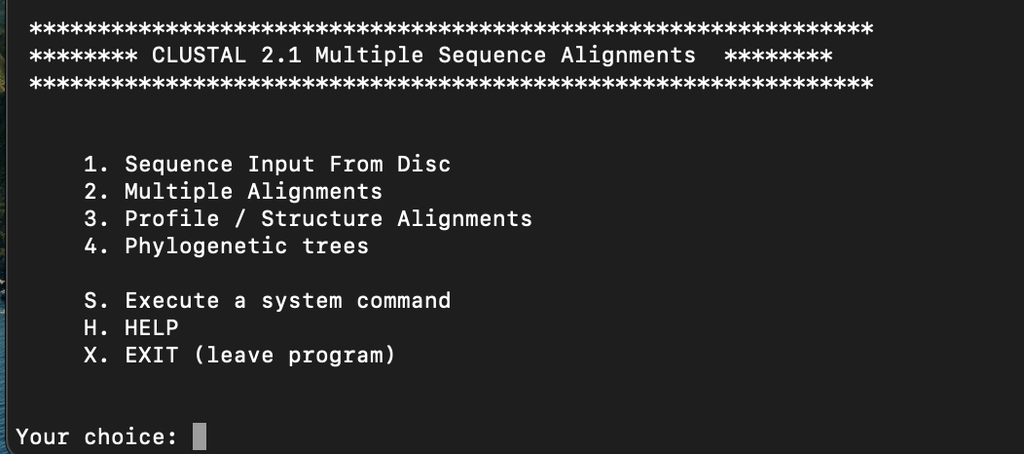

```
Prestin
Alignment with 6 rows and 2238 columns
ATGGATCATGCTGAAGAAAATGAAATCCTTGCAGCAACCCAGAA...--- NE|Cynopterus_sphinx
ATGGATCATGCTGAAGAAAATGAAATCCTCGCAGCAACCCAGAG...--- NE|Pteropus_vampyrus
ATGGATCATGCTGAAGAAAATGAAATCCTTGCAGCAACCCAGAG...TAG NE|Homo_sapiens
ATGGATCATGCTGAAGAAACTGAAATCCTTGCAGCGACCCAGAA...--- E|Eptesicus_fuscus
ATGGATCATGTTGAAGAAACTGAAATCCTTGCAGCAACCCAGCG...--- E|Orcinus_orca
--------------------------------------------...--- E|Hipposideros_armiger
```

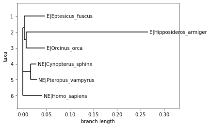

```
GJB2
Alignment with 5 rows and 681 columns
ATGGATTGGAGCACTCTGCACACTATTCTGGGGGGTGTCAATAA...TAA E|Eptesicus_fuscus
ATGGACTGGAGCACTTTGCAGACTATTCTGGGGGGTGTCAATAA...TAA E|Hipposideros_armiger
ATGGATTGGGGCACGCTGCAGACGATCCTGGGGGGTGTGAACAA...TAA NE|Homo_sapiens
ATGGACTGGGGCACGTTGCAGACGATCTTGGGGGGCGTGAACAA...TAA E|Orcinus_orca
ATGGATTGGGGCGCTTTGCAGACCATCCTCGGGGGCGTGAACAA...TAG NE|Pteropus_vampyrus
```

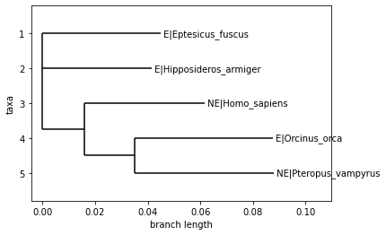

```
CDH23
Alignment with 4 rows and 10108 columns
ATGAGGTGCCACGTTGCCACCAGCTGCCGCGTGGTGTGGCTGTT...--- E|Eptesicus_fuscus
ATGAGGTACCACGTCACCACCAGCTGCCGTGTGGTCTGGCTTTT...--- E|Hipposideros_armiger
ATGAGGTGCCACGTCGCTTCCAGCTGCCTCGTGGTCTGGCTGTC...--- E|Orcinus_orca
ATGGGGCGCCATGTTGCCACCAGCTGCCACGTGGCCTGGCTTTT...TGA NE|Homo_sapiens
```

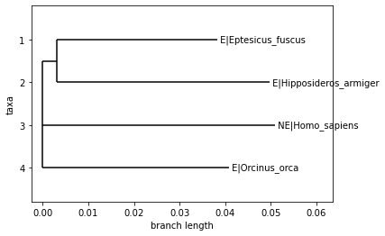

```
PCDH15
Alignment with 6 rows and 7036 columns
--------------------------------------------...--- E|Hipposideros_armiger
--------------------------------------------...TAA NE|Pteropus_vampyrus
--------------------------------------------...--- NE|Cynopterus_sphinx
--------------------------------------------...--- E|Eptesicus_fuscus
ATGACTGACCCTAAAGAAATGGAGGTCTATGAACTGTCTGACAA...--- E|Orcinus_orca
--------------------------------------------...--- NE|Homo_sapiens
```

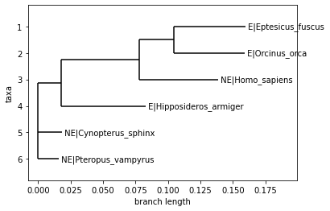

```
OTOF
Alignment with 6 rows and 6048 columns
--------------------------------------------...--- NE|Cynopterus_sphinx
ATGGCCCTGCTCGTCCACCTCAAGACGGTCTCGGAGCTGCGGGG...TGA NE|Pteropus_vampyrus
ATGGCCCTGCTCGTCCACCTCAAGACGGTCTCAGAGCTGCGGGG...TGA E|Hipposideros_armiger
ATGGCCCTGCTCGTCCACCTCAAGACCGTCTCGGAGCTGCGGGG...TGA E|Eptesicus_fuscus
ATGGCTCTGTTCGTCCACCTCAAGACGGTCTCCGAGCTGCGGGG...TGA E|Orcinus_orca
ATGGCCTTGCTCATCCACCTCAAGACAGTCTCGGAGCTGCGGGG...TGA NE|Homo_sapiens
```

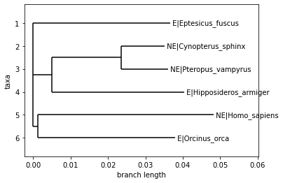

```
KCNQ4
Alignment with 6 rows and 2146 columns
ATGGCCGAGGCCCCCCCGCGCCGCCTCGGCCTAGCCCCCCTGCC...TGA E|Orcinus_orca
ATGGCCGAGGCCCCCCCGCGCCGCCTCGGCCTGGGTCCCCCGCC...TGA NE|Homo_sapiens
--------------------------------------------...TGA E|Eptesicus_fuscus
--------------------------------------------...TGA E|Hipposideros_armiger
--------------------------------------------...--- NE|Cynopterus_sphinx
--------------------------------------------...TGA NE|Pteropus_vampyrus
```

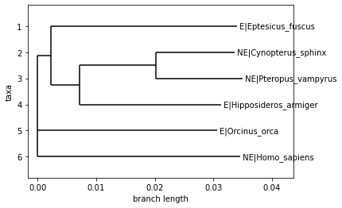

```python
## print name of gene being aligned
print("Prestin")
# read in the alignment output file from performing clustalw2 in computer terminal, use read() function of ALignIO
# define global variable align
align = AlignIO.read("prestin.aln", "clustal")
# view alignment
print(align)
# read in phylogenetic tree created after multiple sequence analysis was performed
# define global variable tree
tree = Phylo.read("prestin.ph", "newick")
# display the tree
Phylo.draw(tree)

# repeat with other alignments/trees:
# note: some species did not have certain gene sequences available

print("GJB2")
align = AlignIO.read("GJB2.aln", "clustal")
print(align)
tree = Phylo.read("GJB2.ph", "newick")
Phylo.draw(tree)

print("CDH23")
align = AlignIO.read("CDH23.aln", "clustal")
print(align)
tree = Phylo.read("CDH23.ph", "newick")
Phylo.draw(tree)

print("PCDH15")
align = AlignIO.read("PCDH15.aln", "clustal")
print(align)
tree = Phylo.read("PCDH15.ph", "newick")
Phylo.draw(tree)

print("OTOF")
align = AlignIO.read("OTOF.aln", "clustal")
print(align)
tree = Phylo.read("OTOF.ph", "newick")
Phylo.draw(tree)

print("KCNQ4")
align = AlignIO.read("KCNQ4.aln", "clustal")
print(align)
tree = Phylo.read("KCNQ4.ph", "newick")
Phylo.draw(tree)
```

### Using multiple sequence alignment and phylogenetic trees, we see that prestin is the only gene where all echolocating species are clustered together.

## Multiple sequence alignment using mafft

Here is the multiple sequence alignment of prestin to show how it would look using mafft instead. I went with clustalw2 because I liked the way the phylogenetic tree looked better.

```
mafft prestin.txt
Alignment with 6 rows and 2248 columns
atggatcatgctgaagaaactgaaatccttgcagcgacccagaa...tga E|Eptesicus_fuscus
atggatcatgctgaagaaaatgaaatccttgcagcaacccagaa...tag NE|Cynopterus_sphinx
--------------------------------------------...--- E|Hipposideros_armiger
atggatcatgctgaagaaaatgaaatccttgcagcaacccagag...tag NE|Homo_sapiens
atggatcatgttgaagaaactgaaatccttgcagcaacccagcg...tag E|Orcinus_orca
atggatcatgctgaagaaaatgaaatcctcgcagcaacccagag...tag NE|Pteropus_vampyrus
```

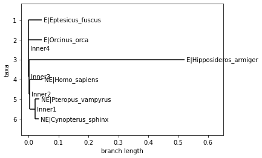

```python
# define global variable in_file which represents the file containing sequence of prestin gene
in_file = "prestin.txt"
# use command line wrapper for mafft, input is the sequence, output is stdout (contains alignment) and stderr
mafft_cline = MafftCommandline(input=in_file)
# check if it worked
print(mafft_cline)

# define global variables stdout, stderr
# assign output variables
stdout, stderr = mafft_cline()
# instead of saving output to file, parse the output with AlignIO directly
# use StringIO to turn string into handle
align = AlignIO.read(StringIO(stdout), "fasta")
print(align)

## make phylogenetic tree
# define global variable constructor -- DistanceTreeConstructor is a distance based tree constructor
constructor = DistanceTreeConstructor()
# define global variable calculator -- DistanceCalculator is distance matrix calculator for MSA
calculator = DistanceCalculator('identity')
# define global variable dm -- use calculator to calculate distances for alignment of prestin
dm = calculator.get_distance(align)
# define global variable njtree -- neighbor joining tree based off calculated distances
njtree = constructor.nj(dm)
# flip branches so deeper clades are displayed at top
njtree.ladderize()
# plot the tree
Phylo.draw(njtree)
```

# Analysis 2: RNAseq - explicitly calculating differential gene expression/Volcano Plot

I could not get pyrpipe or DESeq2 to run so I have performed these calculations instead.

Volcano plot is a type of scatterplot that is commonly used to display the results of RNA-seq. It shows the p-value versus magnitude of change. This allows us to visualize which genes have large changes that are also statistically significant. We input the values from performing differential gene expression calculations. The dots that are outermost and towards the top are likely to be the most biologically significant genes.

### Read in data

```python
# Read in the counts of gene data from csv file
# define global variable counts -- a dataframe containing the gene name and counts of reads for each species
counts = pd.read_csv("counts.csv")

# Read in the metadata
# define global variable metadata -- tells which species are control (non-echolocating) or echolocating
metadata = pd.read_csv('metadata.csv')
# Set the index to the id (names of species)
metadata = metadata.set_index('id')

# code checks
print(counts)
print(metadata)
```

```
                  ensgene  Hipposideros armiger  Rhinolophus affinis  \
0      ENSMLUG00000005825                111.07                37.57
1      ENSMLUG00000006703                 33.12                 0.00
2      ENSMLUG00000012660                  4.52                 0.00
3      ENSMLUG00000001813                  0.00                 0.00
4      ENSMLUG00000012253                 20.24                11.08
...                   ...                   ...                  ...
10855  ENSMLUG00000015351                125.71                91.18
10856  ENSMLUG00000003292                 60.96                84.38
10857  ENSMLUG00000012022                 85.17                80.66
10858  ENSMLUG00000013406                  8.03                 1.54
10859  ENSMLUG00000022670                  0.00                12.49

       Myotis laniger  Miniopterus fuliginosus  Taphozous melanopogon  \
0               27.47                    30.97                  54.30
1                0.00                    26.40                   0.00
2                4.67                     4.32                   4.84
3                0.00                     0.00                  18.89
4                0.00                     0.00                  33.91
...               ...                      ...                    ...
10855          100.80                    65.77                 108.02
10856          106.14                    56.95                 112.03
10857           66.98                    56.24                 103.80
10858            3.52                     5.31                   8.07
10859            0.00                     0.00                   0.00

       Cynopterus sphinx  Rousettus leschenaultia  Eonycteris spelaea
0                 130.67                    70.23               37.12
1                  32.36                     0.00                0.00
2                   6.86                     3.12                6.13
3                   0.00                     0.00                7.05
4                  12.90                    15.40               20.18
...                  ...                      ...                 ...
10855              85.41                    76.46               70.02
10856             218.88                   109.99               87.21
10857              48.34                    57.94               39.65
10858               5.24                    11.07                5.47
10859               0.00                     0.00                0.00

[10860 rows x 9 columns]
                            condition
id
Hipposideros armiger     echolocating
Rhinolophus affinis      echolocating
Myotis laniger           echolocating
Miniopterus fuliginosus  echolocating
Taphozous melanopogon    echolocating
Cynopterus sphinx             control
Rousettus leschenaultia       control
Eonycteris spelaea            control
```

### Calculate differential expression

```python
# parse the counts dataframe just for the control (non-echolocating) experiments
# define global variable control_exp -- contains the names of each species that are non-echolocating
control_exp = list(metadata.loc[metadata['condition'] == 'control'].index)
print(control_exp)

# parse the counts dataframe just for the echolocating experiments
# define global variable echolocating_exp -- contains the names of each species that are echolocating
echolocating_exp = list(metadata.loc[metadata['condition'] == 'echolocating'].index)
print(echolocating_exp)
```

```
['Cynopterus sphinx', 'Rousettus leschenaultia', 'Eonycteris spelaea']
['Hipposideros armiger', 'Rhinolophus affinis', 'Myotis laniger', 'Miniopterus fuliginosus', 'Taphozous melanopogon']
```

```python
## Add a column to the counts dataframe that has the total sum of reads for each gene depending on condition
# Sum control column
counts['Sum control'] = counts[control_exp].sum(axis=1)
# Sum echolocating column
counts['Sum echolocating'] = counts[echolocating_exp].sum(axis=1)
#print(counts.head()) # uncomment for code check

## Calculate the mean and standard deviation to use later when calculating the p-value, add columns to controls df
# Mean number of reads for controls
counts['Mean control'] = counts[control_exp].mean(axis=1)
# Mean number of reads for echolocating
counts['Mean echolocating'] = counts[echolocating_exp].mean(axis=1)
# Standard deviation of reads for control
counts['STD controls'] = counts[control_exp].std(axis=1)
# Standard deviation of reads for echolocating
counts['STD echolocating'] = counts[echolocating_exp].std(axis=1)
```

Note: gene length is excluded from calculations below due to the data not being available from NCBI GEO. I also tried to use Biomart to get the gene lengths but the code and online version weren't working successfully.

```python
# Add a row that has the sum of each column to the counts dataframe
# define global variable Sum_Dict
Sum_Dict = {'ensgene': 'total Column Count',
            'Hipposideros armiger': counts['Hipposideros armiger'].sum(),
            'Rhinolophus affinis': counts['Rhinolophus affinis'].sum(),
            'Myotis laniger': counts['Myotis laniger'].sum(),
            'Miniopterus fuliginosus': counts['Miniopterus fuliginosus'].sum(),
            'Taphozous melanopogon': counts['Taphozous melanopogon'].sum(),
            'Cynopterus sphinx': counts['Cynopterus sphinx'].sum(),
            'Rousettus leschenaultia': counts['Rousettus leschenaultia'].sum(),
            'Eonycteris spelaea': counts['Eonycteris spelaea'].sum(),
            'Sum control': counts['Sum control'].sum(),
            'Sum echolocating': counts['Sum echolocating'].sum()
           }
# update our counts dataframe to include the row that has the sum of each column
counts = counts.append(Sum_Dict, ignore_index = True)
# change the index of the counts dataframe to the gene id
counts = counts.set_index('ensgene')
print(counts)
```

```
                    Hipposideros armiger  Rhinolophus affinis  Myotis laniger  \
ensgene
ENSMLUG00000005825                111.07                37.57           27.47
ENSMLUG00000006703                 33.12                 0.00            0.00
ENSMLUG00000012660                  4.52                 0.00            4.67
ENSMLUG00000001813                  0.00                 0.00            0.00
ENSMLUG00000012253                 20.24                11.08            0.00
...                                  ...                  ...             ...
ENSMLUG00000003292                 60.96                84.38          106.14
ENSMLUG00000012022                 85.17                80.66           66.98
ENSMLUG00000013406                  8.03                 1.54            3.52
ENSMLUG00000022670                  0.00                12.49            0.00
total Column Count             398534.20            442722.80       455822.73

                    Miniopterus fuliginosus  Taphozous melanopogon  \
ensgene
ENSMLUG00000005825                    30.97                  54.30
ENSMLUG00000006703                    26.40                   0.00
ENSMLUG00000012660                     4.32                   4.84
ENSMLUG00000001813                     0.00                  18.89
ENSMLUG00000012253                     0.00                  33.91
...                                     ...                    ...
ENSMLUG00000003292                    56.95                 112.03
ENSMLUG00000012022                    56.24                 103.80
ENSMLUG00000013406                     5.31                   8.07
ENSMLUG00000022670                     0.00                   0.00
total Column Count                423524.70              429722.61

                    Cynopterus sphinx  Rousettus leschenaultia  \
ensgene
ENSMLUG00000005825             130.67                    70.23
ENSMLUG00000006703              32.36                     0.00
ENSMLUG00000012660               6.86                     3.12
ENSMLUG00000001813               0.00                     0.00
ENSMLUG00000012253              12.90                    15.40
...                               ...                      ...
ENSMLUG00000003292             218.88                   109.99
ENSMLUG00000012022              48.34                    57.94
ENSMLUG00000013406               5.24                    11.07
ENSMLUG00000022670               0.00                     0.00
```

[output cut: 30 more lines]

```
                    STD echolocating
ensgene
ENSMLUG00000005825         34.446991
ENSMLUG00000006703         16.472464
ENSMLUG00000012660          2.060510
ENSMLUG00000001813          8.447865
ENSMLUG00000012253         14.416323
...                              ...
ENSMLUG00000003292         25.191798
ENSMLUG00000012022         18.148264
ENSMLUG00000013406          2.847443
ENSMLUG00000022670          5.585698
total Column Count               NaN

[10861 rows x 14 columns]
```

```python
## Calculate the FPKM for the control and the echolocating experiment. Note: lengths of each gene not included
# calculate the FPKM for controls, add column to counts df
counts['FPKM_controls'] = ((counts['Sum control'] * (10 ** 9))) * (counts.loc['total Column Count']['Sum control'])
# calculate the FPKM for echolocating, add column to counts df
counts['FPKM_echolocating'] = ((counts['Sum echolocating'] * (10 ** 9))) * (counts.loc['total Column Count']['Sum echolocating'])
#print(counts.head()) #uncomment for code check
```

```python
# Calculate the Log Fold Change between the two conditions (echolocating vs control)
# define global variable Fold_change
Fold_change = counts['FPKM_echolocating']/counts['FPKM_controls']
# use numpy to calculate the log2 of Fold_change, add to counts df
counts['L2F'] = np.log2(Fold_change)
#print(counts.head()) #uncomment for code check
```

```python
# calculate p-values for each gene using a lambda function, add to counts df
counts['p-value'] = counts.apply(lambda x: stats.ttest_ind_from_stats(x['Mean control'],x['STD controls'],x['Sum control'], x['Mean echolocating'],x['STD echolocating'],x['Sum echolocating'])[1],axis=1)
#print(counts.head()) #uncomment for code check
```

```python
# change setting of display for df to include more decimal places
pd.set_option('display.float_format', lambda x: '%.20f' % x)
# calculate adjusted p-value, add to counts df
counts['adjusted-p-value'] = multipletests(counts['p-value'], alpha=.05, method='bonferroni')[1]
#print(counts) #uncomment for code check
```

## Volcano plot

```python
# remove rows with NaN values to plot with visuz
counts_processed = counts.dropna()

# reset index so that we can use ensgene as labels
counts_processed.reset_index(inplace=True)
print(counts_processed)
```

```
                  ensgene     Hipposideros armiger     Rhinolophus affinis  \
0      ENSMLUG00000005825 111.06999999999999317879 37.57000000000000028422
1      ENSMLUG00000006703  33.11999999999999744205  0.00000000000000000000
2      ENSMLUG00000012660   4.51999999999999957367  0.00000000000000000000
3      ENSMLUG00000001813   0.00000000000000000000  0.00000000000000000000
4      ENSMLUG00000012253  20.23999999999999843681 11.08000000000000007105
...                   ...                      ...                     ...
10759  ENSMLUG00000015351 125.70999999999999374722 91.18000000000000682121
10760  ENSMLUG00000003292  60.96000000000000085265 84.37999999999999545253
10761  ENSMLUG00000012022  85.17000000000000170530 80.65999999999999658939
10762  ENSMLUG00000013406   8.02999999999999936051  1.54000000000000003553
10763  ENSMLUG00000022670   0.00000000000000000000 12.49000000000000021316

                Myotis laniger  Miniopterus fuliginosus  \
0      27.46999999999999886313  30.96999999999999886313
```

[output cut: 116 more lines]

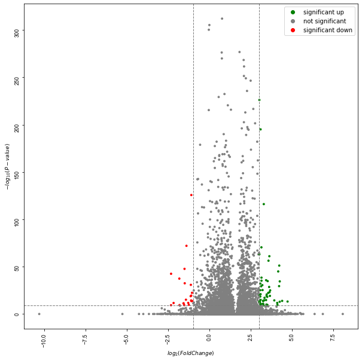

```
posx and posy should be finite values
posx and posy should be finite values
```

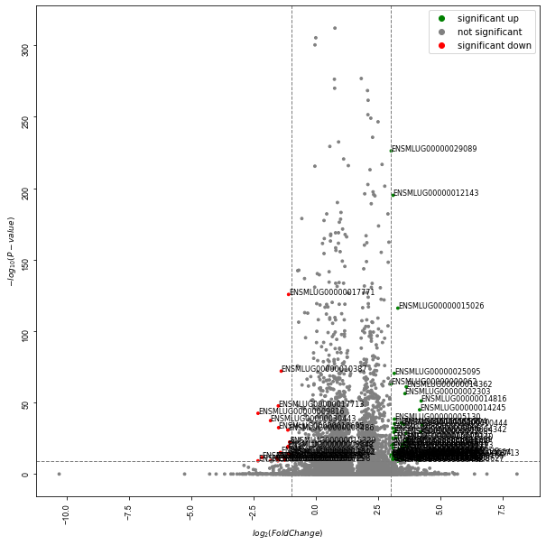

```python
## plot log2(Fold Change) vs Adjusted p-value to see which genes are most differentially expressed
# volcano plot
visuz.GeneExpression.volcano(df=counts_processed, lfc='L2F', pv='adjusted-p-value', lfc_thr=(3, 1), pv_thr=(0.000000001, 0.000000001), show=True, plotlegend =True, dim=(10,10), sign_line=True)
# volcano plot with gene labels
visuz.GeneExpression.volcano(df=counts_processed, lfc='L2F', pv='adjusted-p-value', lfc_thr=(3, 1), pv_thr=(0.000000001, 0.000000001), show=True, plotlegend =True, dim=(10,10), sign_line=True, geneid="ensgene", genenames="deg")
```

# Analysis of Results

The results of the multiple sequence alignments and phylogenetic trees show that prestin is the only gene where echolocating species are all clustered together. Close clustering shows that the sequences are more similar. It does not rule out the importance of the other genes but it shows that prestin likely has a more important role in echolocation.

The results of the differential gene expression analysis and volcano plot show that none of the genes I performed MSA on were significantly differentially expressed. This is likely because the data comes from brain samples, not inner ear samples (which is where prestin is expressed). However, the top genes here that are differentially expressed could be explored more as to their roles in echolocation. Two of the top up-regulated genes, ENSMLUG00000029089 which codes for ribosomal protein 16 and ENSMLUG00000015026 which codes for KLHDC3, when put through reactome shows they both have roles in cellular responses to stimuli.